# Problem Statement - Credit Card Users Churn Prediction

## **Problem Statements**

### **Context**

The Thera bank recently saw a steep decline in the number of users of their credit card, credit cards are a good source of income for banks because of different kinds of fees charged by the banks like annual fees, balance transfer fees, and cash advance fees, late payment fees, foreign transaction fees, and others. Some fees are charged to every user irrespective of usage, while others are charged under specified circumstances.

### **Objective**

Customers’ leaving credit cards services would lead bank to loss, so the bank wants to analyze the data of customers and identify the customers who will leave their credit card services and reason for same – so that bank could improve upon those areas

You as a Data scientist at Thera bank need to come up with a classification model that will help the bank improve its services so that customers do not renounce their credit cards

### **Data Description**

**Data Dictionary**

- **CLIENTNUM:** Client number. Unique identifier for the customer holding the account
- **Attrition_Flag:** Internal event (customer activity) variable - if the account is closed then "Attrited Customer" else "Existing Customer"
- **Customer_Age:** Age in Years
- **Gender:** Gender of the account holder
- **Dependent_count:** Number of dependents
- **Education_Level:** Educational Qualification of the account holder - Graduate, High School, Unknown, Uneducated, College(refers to college student), Post-Graduate, Doctorate
- **Marital_Status:** Marital Status of the account holder
- **Income_Category:** Annual Income Category of the account holder
- **Card_Category:** Type of Card
- **Months_on_book:** Period of relationship with the bank (in months)
- **Total_Relationship_Count:** Total no. of products held by the customer
- **Months_Inactive_12_mon:** No. of months inactive in the last 12 months
- **Contacts_Count_12_mon:** No. of Contacts in the last 12 months
- **Credit_Limit:** Credit Limit on the Credit Card
- **Total_Revolving_Bal:** Total Revolving Balance on the Credit Card
- **Avg_Open_To_Buy:** Open to Buy Credit Line (Average of last 12 months)
- **Total_Amt_Chng_Q4_Q1:** Change in Transaction Amount (Q4 over Q1)
- **Total_Trans_Amt:** Total Transaction Amount (Last 12 months)
- **Total_Trans_Ct:** Total Transaction Count (Last 12 months)
- **Total_Ct_Chng_Q4_Q1:** Change in Transaction Count (Q4 over Q1)
- **Avg_Utilization_Ratio:** Average Card Utilization Ratio

## **Importing the necessary libraries**

```python
# Libraries to help with reading and manipulating data
import pandas as pd
import numpy as np

# libaries to help with data visualization
import matplotlib.pyplot as plt
import seaborn as sns

# To be used for missing value imputation
from sklearn.impute import SimpleImputer

# To help with model building
from sklearn.linear_model import LogisticRegression
from sklearn.tree import DecisionTreeClassifier
from sklearn.ensemble import (
    AdaBoostClassifier,
    GradientBoostingClassifier,
    RandomForestClassifier,
    BaggingClassifier,
)
from xgboost import XGBClassifier

# To get different metric scores, and split data
from sklearn import metrics
from sklearn.model_selection import train_test_split, StratifiedKFold, cross_val_score
from sklearn.metrics import (
    f1_score,
    accuracy_score,
    recall_score,
    precision_score,
    confusion_matrix,
    roc_auc_score,
    ConfusionMatrixDisplay,
)

# To be used for data scaling and one hot encoding
from sklearn.preprocessing import StandardScaler, MinMaxScaler, OneHotEncoder

# To be used for tuning the model
from sklearn.model_selection import GridSearchCV, RandomizedSearchCV

# To be used for creating pipelines and personalizing them
from sklearn.pipeline import Pipeline
from sklearn.compose import ColumnTransformer

# To oversample and undersample data
from imblearn.over_sampling import SMOTE
from imblearn.under_sampling import RandomUnderSampler

# To build model for prediction
from sklearn.tree import DecisionTreeClassifier
from sklearn import tree

# Removes the limit for the number of displayed columns
pd.set_option("display.max_columns", None)

# Sets the limit for the number of displayed rows
pd.set_option("display.max_rows", 100)

# To supress scientific notations for a dataframe
pd.set_option("display.float_format", lambda x: "%.3f" % x)

# To supress warnings
import warnings
warnings.filterwarnings("ignore")
```

## **Loading the dataset**

```python
from google.colab import drive
drive.mount('/content/drive')
```

```python
# read the data from the drive
file_path = r"/content/drive/BankChurners.csv"
data = pd.read_csv(file_path)
```

## **Data Overview**

#### **Create a copy of the data**

```python
# let's create a copy of the data to avoid any changes to original data
df = data.copy()
```

#### **Displaying the first & last few rows of the dataset**

```python
# view the first 5 rows
df.head()
```

|  | CLIENTNUM | Attrition_Flag | Customer_Age | Gender | Dependent_count | Education_Level | Marital_Status | Income_Category | Card_Category | Months_on_book | Total_Relationship_Count | Months_Inactive_12_mon | Contacts_Count_12_mon | Credit_Limit | Total_Revolving_Bal | Avg_Open_To_Buy | Total_Amt_Chng_Q4_Q1 | Total_Trans_Amt | Total_Trans_Ct | Total_Ct_Chng_Q4_Q1 | Avg_Utilization_Ratio |
| --- | --- | --- | --- | --- | --- | --- | --- | --- | --- | --- | --- | --- | --- | --- | --- | --- | --- | --- | --- | --- | --- |
| 0 | 768805383 | Existing Customer | 45 | M | 3 | High School | Married | $60K - $80K | Blue | 39 | 5 | 1 | 3 | 12691.000 | 777 | 11914.000 | 1.335 | 1144 | 42 | 1.625 | 0.061 |
| 1 | 818770008 | Existing Customer | 49 | F | 5 | Graduate | Single | Less than $40K | Blue | 44 | 6 | 1 | 2 | 8256.000 | 864 | 7392.000 | 1.541 | 1291 | 33 | 3.714 | 0.105 |
| 2 | 713982108 | Existing Customer | 51 | M | 3 | Graduate | Married | $80K - $120K | Blue | 36 | 4 | 1 | 0 | 3418.000 | 0 | 3418.000 | 2.594 | 1887 | 20 | 2.333 | 0.000 |
| 3 | 769911858 | Existing Customer | 40 | F | 4 | High School | NaN | Less than $40K | Blue | 34 | 3 | 4 | 1 | 3313.000 | 2517 | 796.000 | 1.405 | 1171 | 20 | 2.333 | 0.760 |
| 4 | 709106358 | Existing Customer | 40 | M | 3 | Uneducated | Married | $60K - $80K | Blue | 21 | 5 | 1 | 0 | 4716.000 | 0 | 4716.000 | 2.175 | 816 | 28 | 2.500 | 0.000 |

```python
# view the last 5 rows
df.tail()
```

|  | CLIENTNUM | Attrition_Flag | Customer_Age | Gender | Dependent_count | Education_Level | Marital_Status | Income_Category | Card_Category | Months_on_book | Total_Relationship_Count | Months_Inactive_12_mon | Contacts_Count_12_mon | Credit_Limit | Total_Revolving_Bal | Avg_Open_To_Buy | Total_Amt_Chng_Q4_Q1 | Total_Trans_Amt | Total_Trans_Ct | Total_Ct_Chng_Q4_Q1 | Avg_Utilization_Ratio |
| --- | --- | --- | --- | --- | --- | --- | --- | --- | --- | --- | --- | --- | --- | --- | --- | --- | --- | --- | --- | --- | --- |
| 10122 | 772366833 | Existing Customer | 50 | M | 2 | Graduate | Single | $40K - $60K | Blue | 40 | 3 | 2 | 3 | 4003.000 | 1851 | 2152.000 | 0.703 | 15476 | 117 | 0.857 | 0.462 |
| 10123 | 710638233 | Attrited Customer | 41 | M | 2 | NaN | Divorced | $40K - $60K | Blue | 25 | 4 | 2 | 3 | 4277.000 | 2186 | 2091.000 | 0.804 | 8764 | 69 | 0.683 | 0.511 |
| 10124 | 716506083 | Attrited Customer | 44 | F | 1 | High School | Married | Less than $40K | Blue | 36 | 5 | 3 | 4 | 5409.000 | 0 | 5409.000 | 0.819 | 10291 | 60 | 0.818 | 0.000 |
| 10125 | 717406983 | Attrited Customer | 30 | M | 2 | Graduate | NaN | $40K - $60K | Blue | 36 | 4 | 3 | 3 | 5281.000 | 0 | 5281.000 | 0.535 | 8395 | 62 | 0.722 | 0.000 |
| 10126 | 714337233 | Attrited Customer | 43 | F | 2 | Graduate | Married | Less than $40K | Silver | 25 | 6 | 2 | 4 | 10388.000 | 1961 | 8427.000 | 0.703 | 10294 | 61 | 0.649 | 0.189 |

#### **Checking 10 random rows of the dataset**

```python
df.sample(n=10, random_state=1)
```

|  | CLIENTNUM | Attrition_Flag | Customer_Age | Gender | Dependent_count | Education_Level | Marital_Status | Income_Category | Card_Category | Months_on_book | Total_Relationship_Count | Months_Inactive_12_mon | Contacts_Count_12_mon | Credit_Limit | Total_Revolving_Bal | Avg_Open_To_Buy | Total_Amt_Chng_Q4_Q1 | Total_Trans_Amt | Total_Trans_Ct | Total_Ct_Chng_Q4_Q1 | Avg_Utilization_Ratio |
| --- | --- | --- | --- | --- | --- | --- | --- | --- | --- | --- | --- | --- | --- | --- | --- | --- | --- | --- | --- | --- | --- |
| 6498 | 712389108 | Existing Customer | 43 | F | 2 | Graduate | Married | Less than $40K | Blue | 36 | 6 | 3 | 2 | 2570.000 | 2107 | 463.000 | 0.651 | 4058 | 83 | 0.766 | 0.820 |
| 9013 | 718388733 | Existing Customer | 38 | F | 1 | College | NaN | Less than $40K | Blue | 32 | 2 | 3 | 3 | 2609.000 | 1259 | 1350.000 | 0.871 | 8677 | 96 | 0.627 | 0.483 |
| 2053 | 710109633 | Existing Customer | 39 | M | 2 | College | Married | $60K - $80K | Blue | 31 | 6 | 3 | 2 | 9871.000 | 1061 | 8810.000 | 0.545 | 1683 | 34 | 0.478 | 0.107 |
| 3211 | 717331758 | Existing Customer | 44 | M | 4 | Graduate | Married | $120K + | Blue | 32 | 6 | 3 | 4 | 34516.000 | 2517 | 31999.000 | 0.765 | 4228 | 83 | 0.596 | 0.073 |
| 5559 | 709460883 | Attrited Customer | 38 | F | 2 | Doctorate | Married | Less than $40K | Blue | 28 | 5 | 2 | 4 | 1614.000 | 0 | 1614.000 | 0.609 | 2437 | 46 | 0.438 | 0.000 |
| 6106 | 789105183 | Existing Customer | 54 | M | 3 | Post-Graduate | Single | $80K - $120K | Silver | 42 | 3 | 1 | 2 | 34516.000 | 2488 | 32028.000 | 0.552 | 4401 | 87 | 0.776 | 0.072 |
| 4150 | 771342183 | Attrited Customer | 53 | F | 3 | Graduate | Single | $40K - $60K | Blue | 40 | 6 | 3 | 2 | 1625.000 | 0 | 1625.000 | 0.689 | 2314 | 43 | 0.433 | 0.000 |
| 2205 | 708174708 | Existing Customer | 38 | M | 4 | Graduate | Married | $40K - $60K | Blue | 27 | 6 | 2 | 4 | 5535.000 | 1276 | 4259.000 | 0.636 | 1764 | 38 | 0.900 | 0.231 |
| 4145 | 718076733 | Existing Customer | 43 | M | 1 | Graduate | Single | $60K - $80K | Silver | 31 | 4 | 3 | 3 | 25824.000 | 1170 | 24654.000 | 0.684 | 3101 | 73 | 0.780 | 0.045 |
| 5324 | 821889858 | Attrited Customer | 50 | F | 1 | Doctorate | Single | abc | Blue | 46 | 6 | 4 | 3 | 1970.000 | 1477 | 493.000 | 0.662 | 2493 | 44 | 0.571 | 0.750 |

#### **Checking the shape of the dataset**

```python
# Checking how many rows and columns are present in the data
df.shape
```

```
(10127, 21)
```

##### Observations:

- There are `*10127 rows*` & `*21 columns*` in the given dataset.

#### **Checking the data types of the columns for the dataset**

```python
# inspecting the dataset
df.info()
```

```
<class 'pandas.core.frame.DataFrame'>
RangeIndex: 10127 entries, 0 to 10126
Data columns (total 21 columns):
 #   Column                    Non-Null Count  Dtype
---  ------                    --------------  -----
 0   CLIENTNUM                 10127 non-null  int64
 1   Attrition_Flag            10127 non-null  object
 2   Customer_Age              10127 non-null  int64
 3   Gender                    10127 non-null  object
 4   Dependent_count           10127 non-null  int64
 5   Education_Level           8608 non-null   object
 6   Marital_Status            9378 non-null   object
 7   Income_Category           10127 non-null  object
 8   Card_Category             10127 non-null  object
 9   Months_on_book            10127 non-null  int64
 10  Total_Relationship_Count  10127 non-null  int64
 11  Months_Inactive_12_mon    10127 non-null  int64
 12  Contacts_Count_12_mon     10127 non-null  int64
 13  Credit_Limit              10127 non-null  float64
 14  Total_Revolving_Bal       10127 non-null  int64
 15  Avg_Open_To_Buy           10127 non-null  float64
 16  Total_Amt_Chng_Q4_Q1      10127 non-null  float64
 17  Total_Trans_Amt           10127 non-null  int64
 18  Total_Trans_Ct            10127 non-null  int64
 19  Total_Ct_Chng_Q4_Q1       10127 non-null  float64
 20  Avg_Utilization_Ratio     10127 non-null  float64
dtypes: float64(5), int64(10), object(6)
memory usage: 1.6+ MB
```

```python
# group by data type
df.dtypes.value_counts()
```

|  | count |
| --- | --- |
| int64 | 10 |
| object | 6 |
| float64 | 5 |

**dtype:** int64

##### Observations:

- *`6 columns`* are of the `object` type columns, *`10 columns`* are of `numerical` type columns, and *`5 columns`* are of `continuous` type columns.
- All the columns don't have `10127 observations`, which means some of the columns have *missing values*.
- `1519` missing data in Education_Level column & `749` missing data in Marital_Status columns.

#### **Statistical summary of the dataset**

```python
# Checking the statistical summary of the data
df.describe().T
```

|  | count | mean | std | min | 25% | 50% | 75% | max |
| --- | --- | --- | --- | --- | --- | --- | --- | --- |
| CLIENTNUM | 10127.000 | 739177606.334 | 36903783.450 | 708082083.000 | 713036770.500 | 717926358.000 | 773143533.000 | 828343083.000 |
| Customer_Age | 10127.000 | 46.326 | 8.017 | 26.000 | 41.000 | 46.000 | 52.000 | 73.000 |
| Dependent_count | 10127.000 | 2.346 | 1.299 | 0.000 | 1.000 | 2.000 | 3.000 | 5.000 |
| Months_on_book | 10127.000 | 35.928 | 7.986 | 13.000 | 31.000 | 36.000 | 40.000 | 56.000 |
| Total_Relationship_Count | 10127.000 | 3.813 | 1.554 | 1.000 | 3.000 | 4.000 | 5.000 | 6.000 |
| Months_Inactive_12_mon | 10127.000 | 2.341 | 1.011 | 0.000 | 2.000 | 2.000 | 3.000 | 6.000 |
| Contacts_Count_12_mon | 10127.000 | 2.455 | 1.106 | 0.000 | 2.000 | 2.000 | 3.000 | 6.000 |
| Credit_Limit | 10127.000 | 8631.954 | 9088.777 | 1438.300 | 2555.000 | 4549.000 | 11067.500 | 34516.000 |
| Total_Revolving_Bal | 10127.000 | 1162.814 | 814.987 | 0.000 | 359.000 | 1276.000 | 1784.000 | 2517.000 |
| Avg_Open_To_Buy | 10127.000 | 7469.140 | 9090.685 | 3.000 | 1324.500 | 3474.000 | 9859.000 | 34516.000 |
| Total_Amt_Chng_Q4_Q1 | 10127.000 | 0.760 | 0.219 | 0.000 | 0.631 | 0.736 | 0.859 | 3.397 |
| Total_Trans_Amt | 10127.000 | 4404.086 | 3397.129 | 510.000 | 2155.500 | 3899.000 | 4741.000 | 18484.000 |
| Total_Trans_Ct | 10127.000 | 64.859 | 23.473 | 10.000 | 45.000 | 67.000 | 81.000 | 139.000 |
| Total_Ct_Chng_Q4_Q1 | 10127.000 | 0.712 | 0.238 | 0.000 | 0.582 | 0.702 | 0.818 | 3.714 |
| Avg_Utilization_Ratio | 10127.000 | 0.275 | 0.276 | 0.000 | 0.023 | 0.176 | 0.503 | 0.999 |

#### **Numerical & Categorical Columns**

```python
numerical_col = df.select_dtypes(include=np.number).columns.tolist()
print(f"Total number of Numerical Columns are: {len(numerical_col)} \n")
numerical_col
```

```
Total number of Numerical Columns are: 15
```

```
['CLIENTNUM',
 'Customer_Age',
 'Dependent_count',
 'Months_on_book',
 'Total_Relationship_Count',
 'Months_Inactive_12_mon',
 'Contacts_Count_12_mon',
 'Credit_Limit',
 'Total_Revolving_Bal',
 'Avg_Open_To_Buy',
 'Total_Amt_Chng_Q4_Q1',
 'Total_Trans_Amt',
 'Total_Trans_Ct',
 'Total_Ct_Chng_Q4_Q1',
 'Avg_Utilization_Ratio']
```

```python
categorical_col = df.select_dtypes(include=['object', 'category']).columns.tolist()
print(f"Total number of Categorical Columns are: {len(categorical_col)} \n")
categorical_col
```

```
Total number of Categorical Columns are: 6
```

```
['Attrition_Flag',
 'Gender',
 'Education_Level',
 'Marital_Status',
 'Income_Category',
 'Card_Category']
```

## **Exploratory Data Analysis (EDA)**

### **Model Support Functions**

```python
# function to create both Histogram & Box-Plot

def histogram_boxplot(data, feature, figsize=(15, 10), kde=False, bins=None):
    """
    Boxplot and histogram combined
    data: dataframe
    feature: dataframe column
    figsize: size of figure (default (15,10))
    kde: whether to show the density curve (default False)
    bins: number of bins for histogram (default None)
    """
    f2, (ax_box2, ax_hist2) = plt.subplots(
        nrows=2,  # Number of rows of the subplot grid= 2
        sharex=True,  # x-axis will be shared among all subplots
        gridspec_kw={"height_ratios": (0.25, 0.75)},
        figsize=figsize,
    )  # creating the 2 subplots
    sns.boxplot(
        # data=data, x=feature, ax=ax_box2, showmeans=True, color="violet"
        data=data, x=feature, ax=ax_box2, showmeans=True
    )  # boxplot will be created and a triangle will indicate the mean value of the column
    sns.histplot(
        data=data, x=feature, kde=kde, ax=ax_hist2, bins=bins
    ) if bins else sns.histplot(
        data=data, x=feature, kde=kde, ax=ax_hist2
    )  # For histogram
    ax_hist2.axvline(
        # data[feature].mean(), color="green", linestyle="--"
        data[feature].mean(), linestyle="--"
    )  # Add mean to the histogram
    ax_hist2.axvline(
        # data[feature].median(), color="black", linestyle="-"
        data[feature].median(), linestyle="-"
    )  # Add median to the histogram
```

```python
def barplot(df, x, y):
  plt.figure(figsize=(12, 6))
  ax = sns.barplot(data=df, x=x, y=y, ci=False, palette="colorblind")
  plt.xticks(rotation=90)

  for p in ax.patches:
    ax.annotate(format(p.get_height(), '.2f'),
                   (p.get_x() + p.get_width() / 2., p.get_height()),
                   ha = 'center', va = 'center',
                   xytext = (0, 9),
                   textcoords = 'offset points')
  plt.show()

  print()

  # Plot Boxplot
  plt.figure(figsize=(12, 6))
  sns.boxplot(data=df, x=x, y=y, palette="colorblind")
  plt.title(f'{x} vs. {y}')
  plt.xticks(rotation=90)
  plt.show()
```

```python
# function to create Barplot

def labeled_barplot(data, feature, perc=False, n=None):
    """
    Barplot with percentage at the top
    data: dataframe
    feature: dataframe column
    perc: whether to display percentages instead of count (default is False)
    n: displays the top n category levels (default is None, i.e., display all levels)
    """

    total = len(data[feature])  # length of the column
    count = data[feature].nunique()
    if n is None:
        plt.figure(figsize=(count + 2, 6))
    else:
        plt.figure(figsize=(n + 2, 6))

    plt.xticks(rotation=90, fontsize=15)
    ax = sns.countplot(
        data=data,
        x=feature,
        palette="deep",
        order=data[feature].value_counts().index[:n],
    )

    for p in ax.patches:
        if perc == True:
            label = "{:.1f}%".format(
                100 * p.get_height() / total
            )  # percentage of each class of the category
        else:
            label = int(p.get_height())  # count of each level of the category without decimals

        x = p.get_x() + p.get_width() / 2  # width of the plot
        y = p.get_height()  # height of the plot

        ax.annotate(
            label,
            (x, y),
            ha="center",
            va="center",
            size=12,
            xytext=(0, 5),
            textcoords="offset points",
        )  # annotate the percentage

    plt.show()  # show the plot
```

### Univariate Analysis

#### Distribution of **`Customer_Age`** *(Numerical Column)*

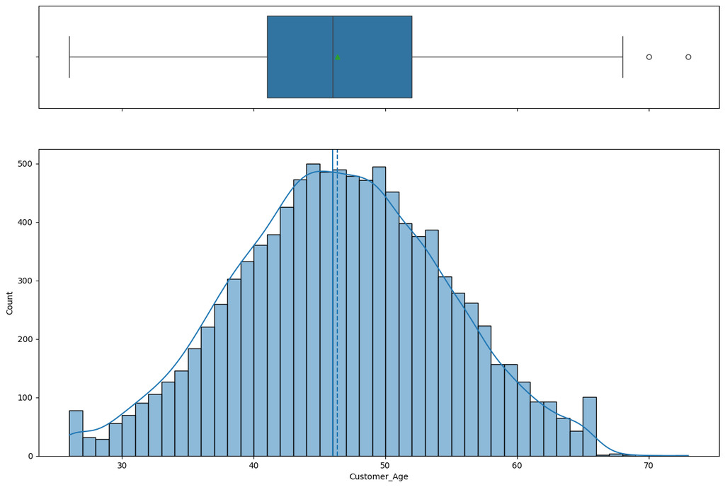

```python
histogram_boxplot(df, "Customer_Age", kde=True)
```

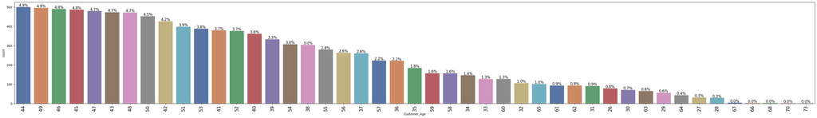

```python
labeled_barplot(df, 'Customer_Age', perc=True);
```

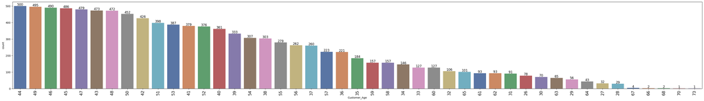

```python
labeled_barplot(df, 'Customer_Age');
```

##### Observations:

- The *Customer_Age* variable approximately follows a normal distribution and contains outliers.

#### Distribution of **`Dependent_count`** *(Numerical Column)*

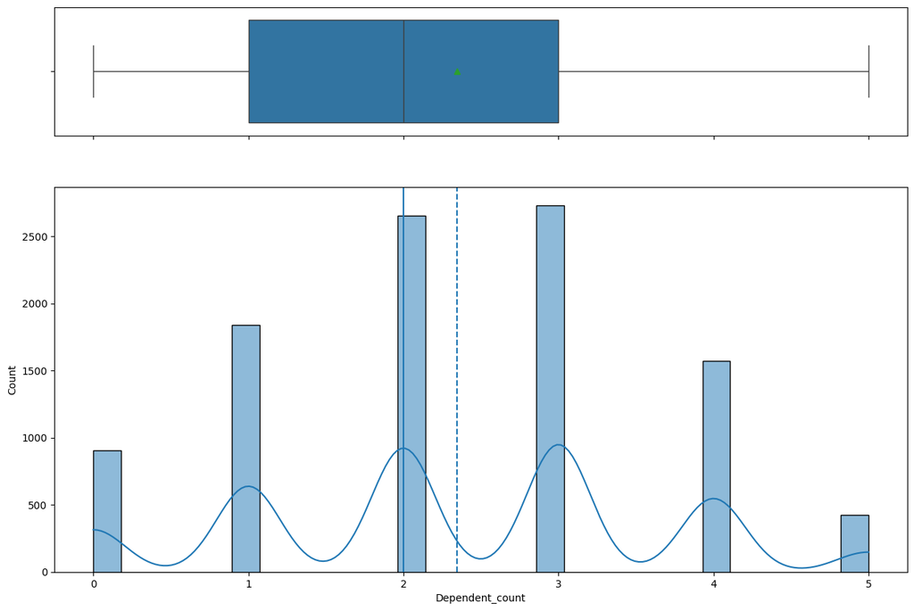

```python
histogram_boxplot(df, "Dependent_count", kde=True)
```

##### Observations:

- The above plot shows multiple peaks, indicating that the data is not normally distributed.

#### Distribution of **`Months_on_book`** *(Numerical Column)*

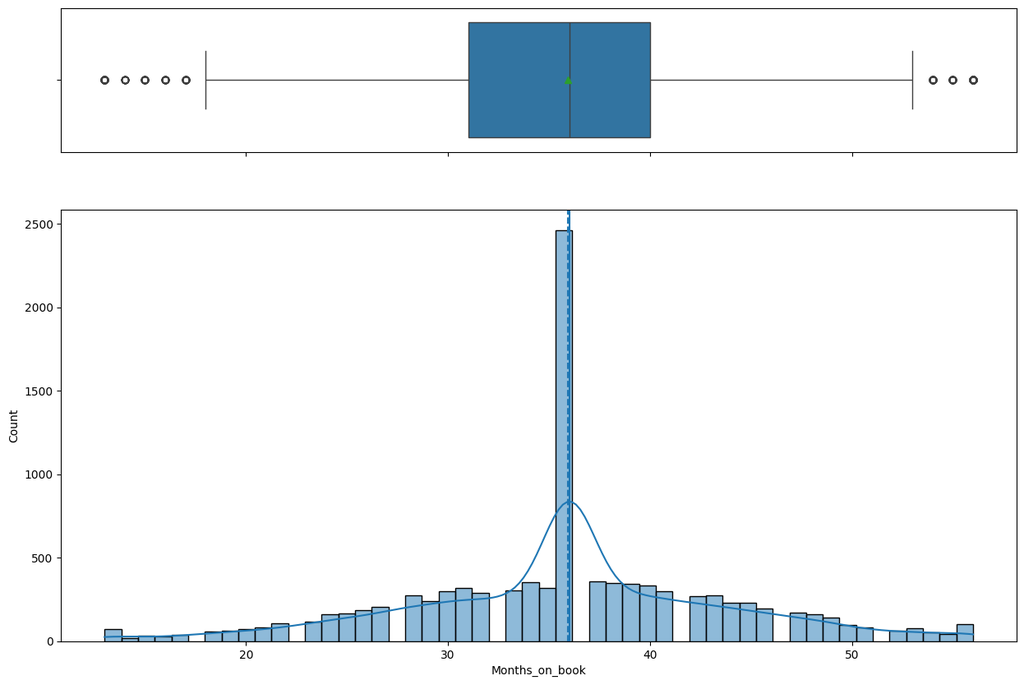

```python
histogram_boxplot(df, "Months_on_book", kde=True)
```

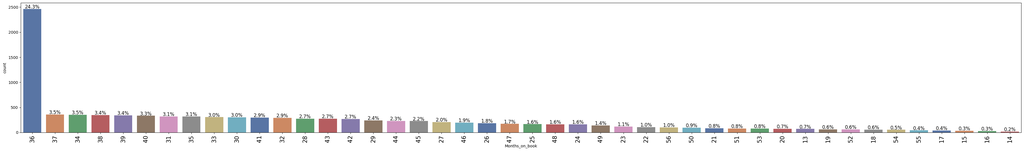

```python
labeled_barplot(df, "Months_on_book", perc=True);
```

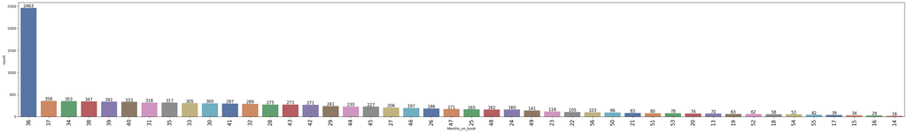

```python
labeled_barplot(df, "Months_on_book");
```

##### Observations:

- The *Months_on_book* variable follows approximately normal but with deviations (due to the sharp peak).
- There are outliers on both sides, meaning some data points lie far from the central range.

#### Distribution of **`Total_Relationship_Count`** *(Numerical Column)*

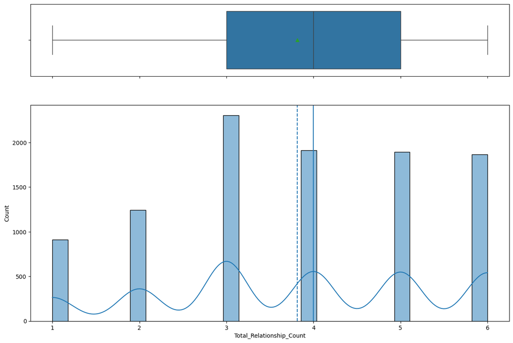

```python
histogram_boxplot(df, "Total_Relationship_Count", kde=True)
```

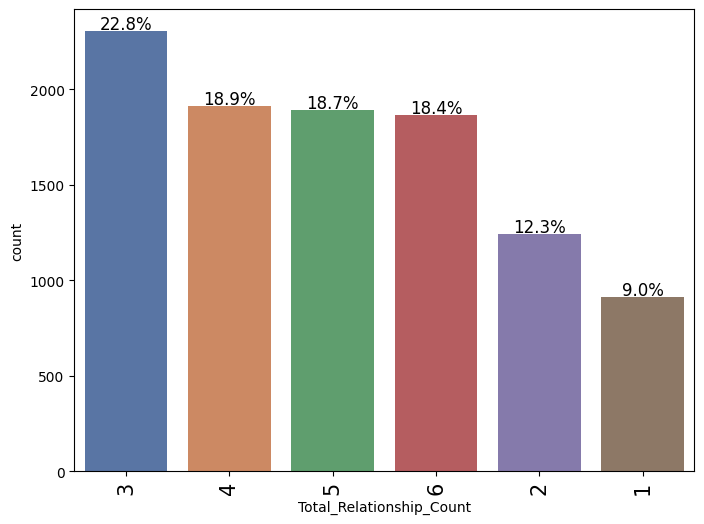

```python
labeled_barplot(df, "Total_Relationship_Count", perc=True);
```

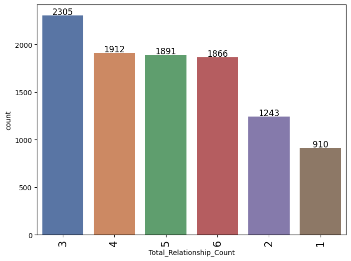

```python
labeled_barplot(df, "Total_Relationship_Count");
```

##### Observations:

- The histogram with KDE plot shows multiple peaks, indicating that the data is not normally distributed.

#### Distribution of **`Months_Inactive_12_mon`** *(Numerical Column)*

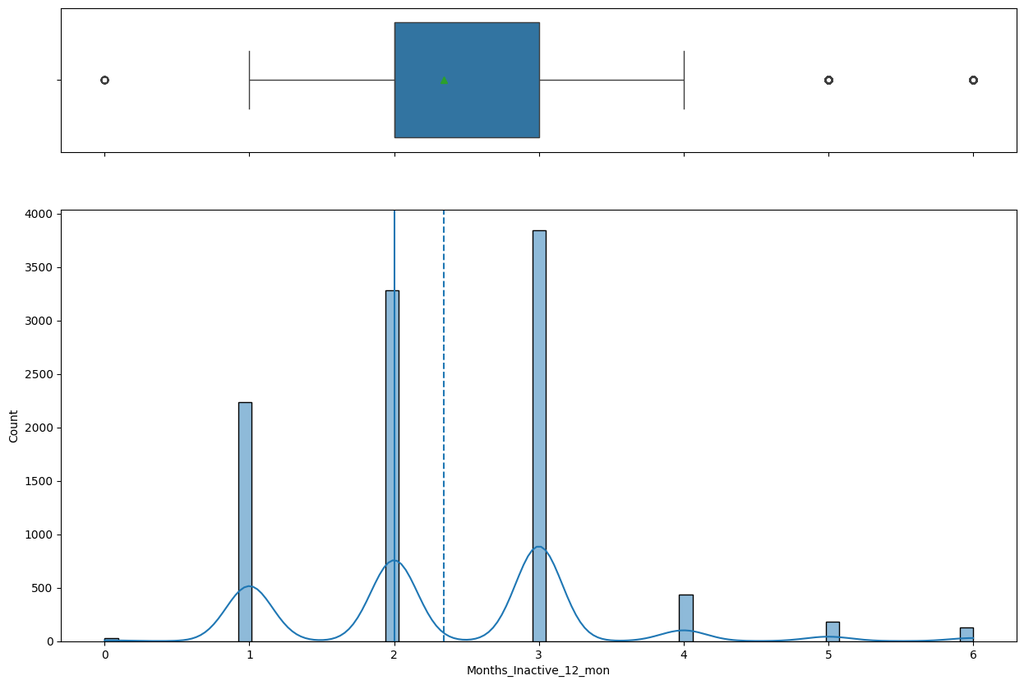

```python
histogram_boxplot(df, "Months_Inactive_12_mon", kde=True)
```

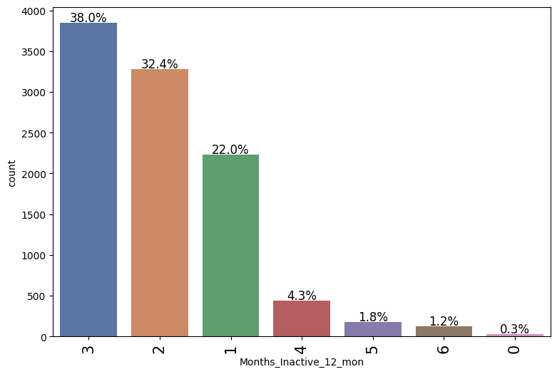

```python
labeled_barplot(df, "Months_Inactive_12_mon", perc=True);
```

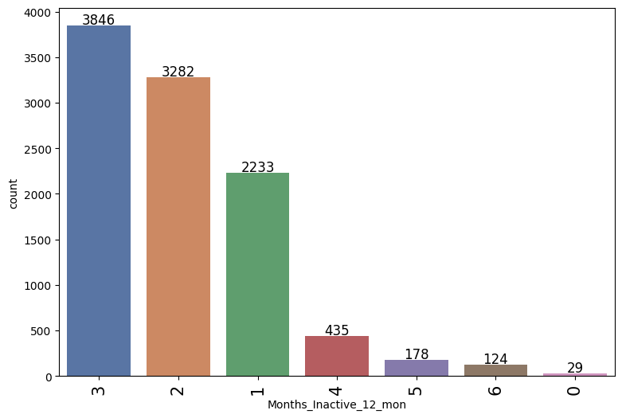

```python
labeled_barplot(df, "Months_Inactive_12_mon");
```

##### Observations:

- The *Months_Inactive_12_mon* variable shows multiple peaks, which suggests that the data follows a multimodal distribution rather than a normal distribution.

#### Distribution of **`Contacts_Count_12_mon`** *(Numerical Column)*

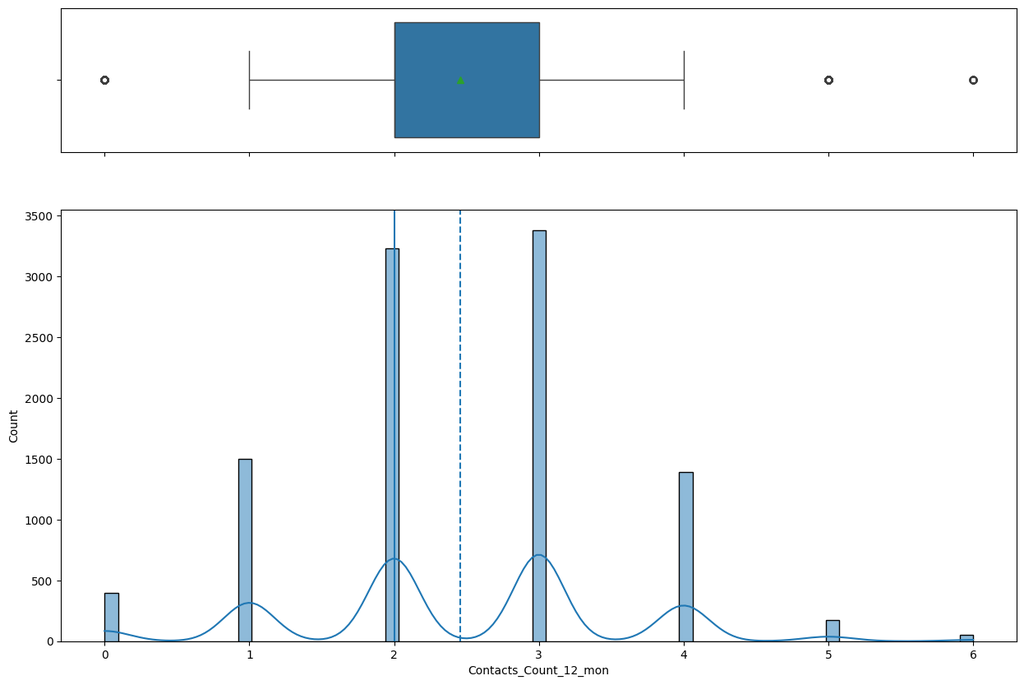

```python
histogram_boxplot(df, 'Contacts_Count_12_mon', kde=True)
```

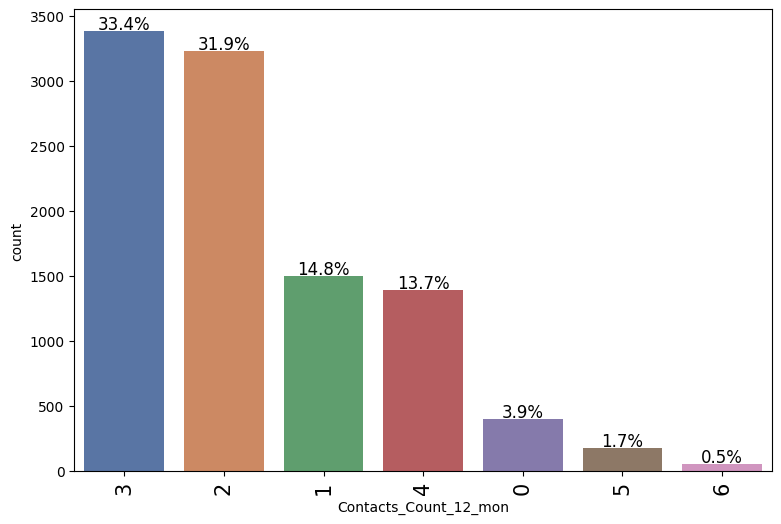

```python
labeled_barplot(df, 'Contacts_Count_12_mon', perc=True);
```

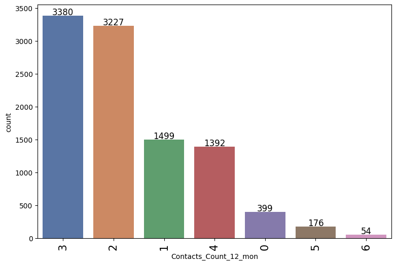

```python
labeled_barplot(df, 'Contacts_Count_12_mon');
```

##### Observations:

- The *Contacts_Count_12_mon* variable shows multiple peaks, which indicates that the data follows a multimodal distribution rather than a normal distribution.

#### Distribution of **`Credit_Limit`** *(Numerical Column)*

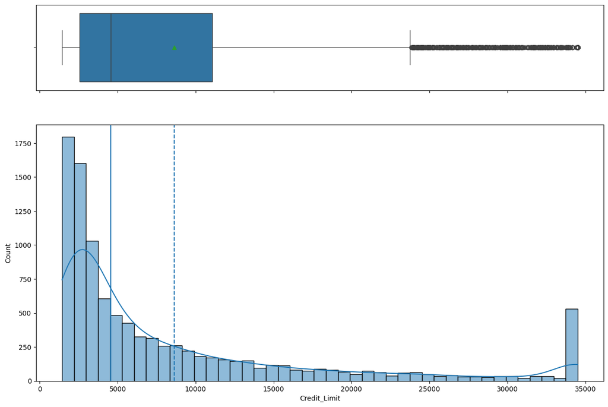

```python
histogram_boxplot(df, "Credit_Limit", kde=True)
```

##### Observations:

- The *Credit_Limit* variable follows highly right-skewed distribution with outliers.

#### Distribution of **`Total_Revolving_Bal`** *(Numerical Column)*

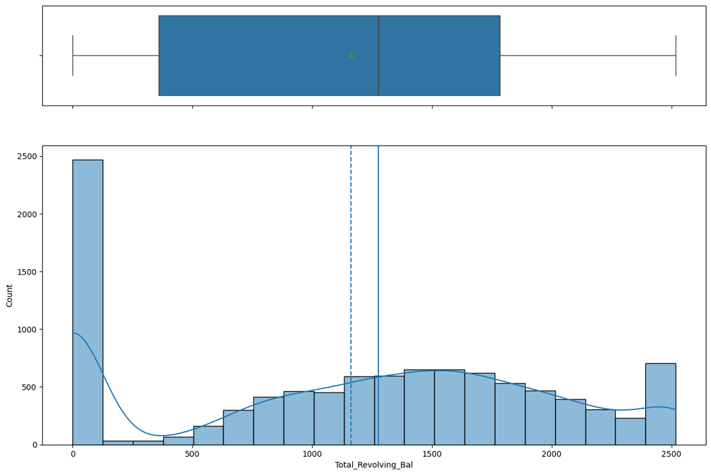

```python
histogram_boxplot(df, "Total_Revolving_Bal", kde=True)
```

#### Distribution of **`Avg_Open_To_Buy`** *(Numerical Column)*

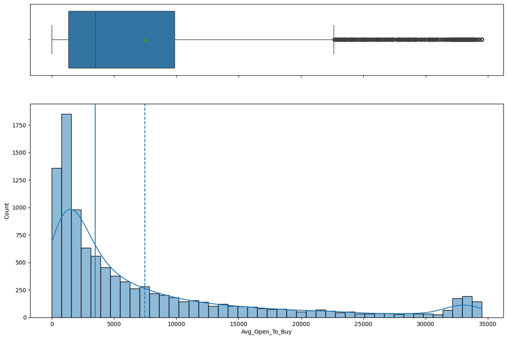

```python
histogram_boxplot(df, "Avg_Open_To_Buy", kde=True)
```

##### Observations:

- The *Avg_Open_To_Buy* variable follows a right-skewed distribution and contains outliers.

#### Distribution of **`Total_Amt_Chng_Q4_Q1`** *(Numerical Column)*

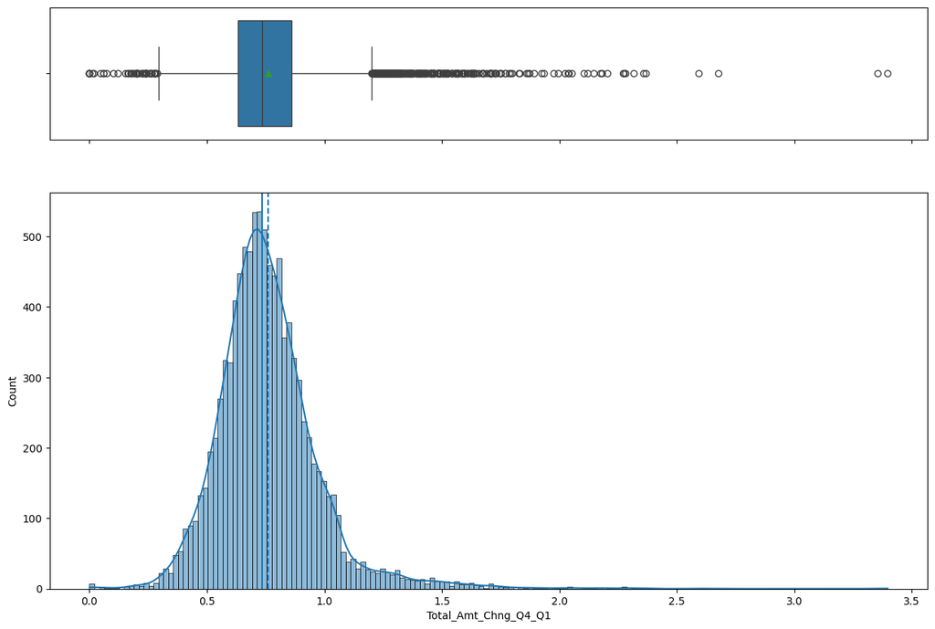

```python
histogram_boxplot(df, "Total_Amt_Chng_Q4_Q1", kde=True)
```

##### Observations:

- The *Total_Amt_Chng_Q4_Q1* variable follows a right-skewed distribution with outliers.

#### Distribution of **`Total_Trans_Amt`** *(Numerical Column)*

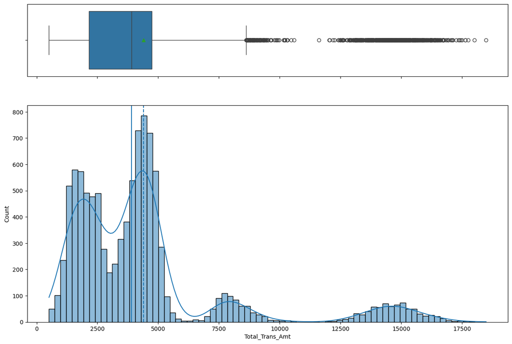

```python
histogram_boxplot(df, "Total_Trans_Amt", kde=True)
```

##### Observations:

- The *Total_Trans_Amt* variable shows multiple peaks, which suggests that the data follows a multimodal distribution rather than a normal distribution.

#### Distribution of **`Total_Trans_Ct`** *(Numerical Column)*

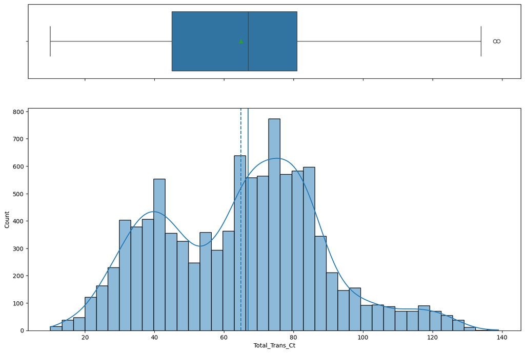

```python
histogram_boxplot(df, "Total_Trans_Ct", kde=True)
```

[figure not shown]

```python
labeled_barplot(df, "Total_Trans_Ct", perc=True);
```

##### Observations:

- The *Total_Trans_CT* variable shows multiple peaks, which suggests that the data follows a multimodal distribution rather than a normal distribution.

#### Distribution of **`Total_Ct_Chng_Q4_Q1`** *(Numerical Column)*

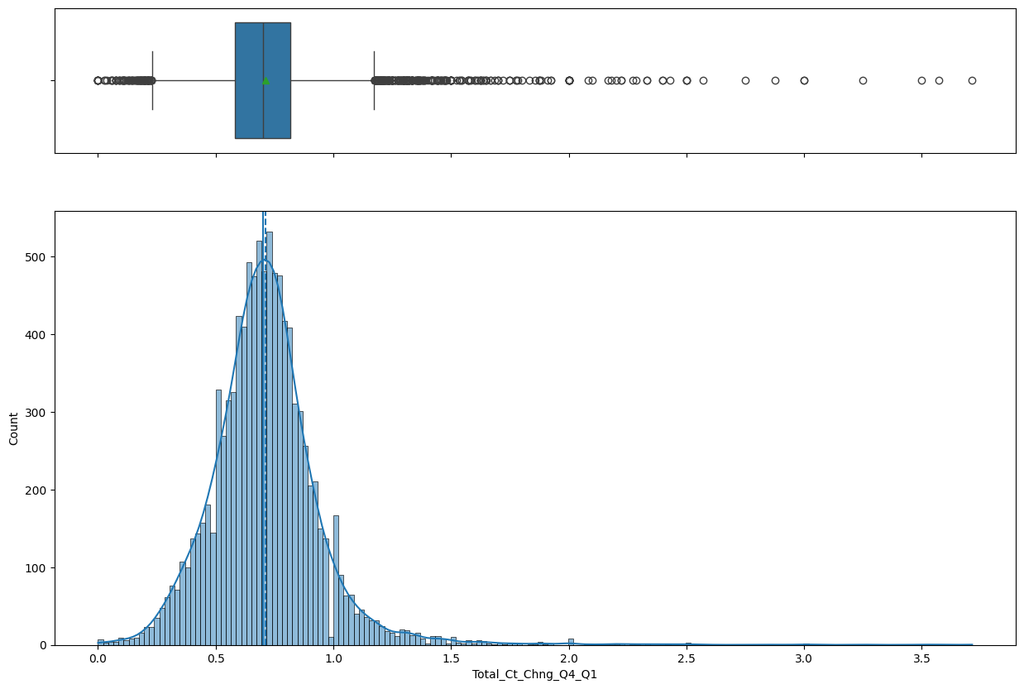

```python
histogram_boxplot(df, "Total_Ct_Chng_Q4_Q1", kde=True)
```

#### Distribution of **`Avg_Utilization_Ratio`** *(Numerical Column)*

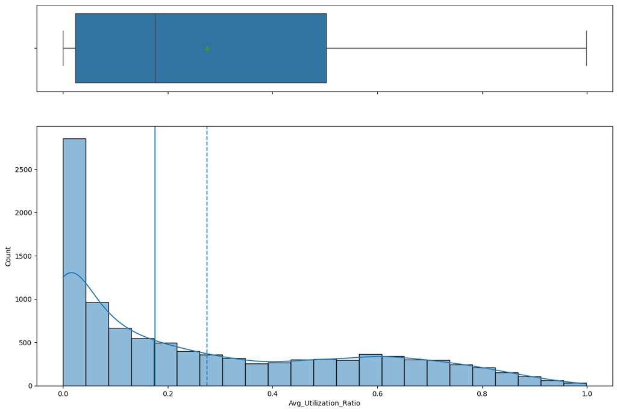

```python
histogram_boxplot(df, "Avg_Utilization_Ratio", kde=True)
```

#### Distribution of **`Attrition_Flag`** *(Categorical Column)*

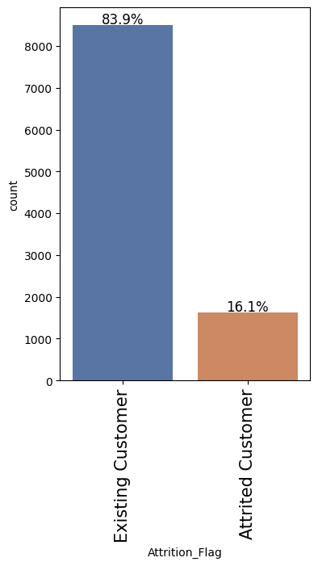

```python
labeled_barplot(df, 'Attrition_Flag', perc=True);
```

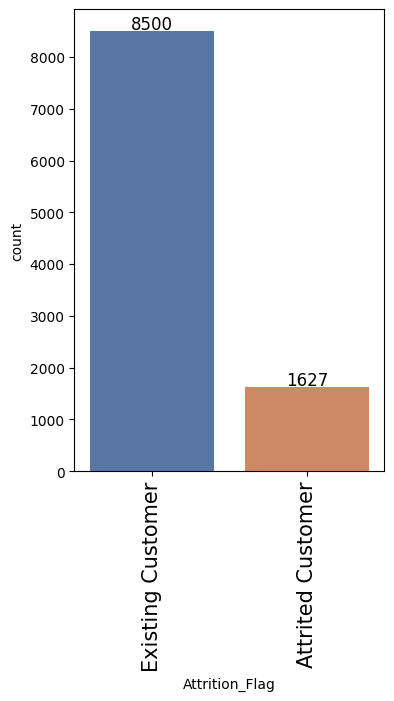

```python
labeled_barplot(df, 'Attrition_Flag');
```

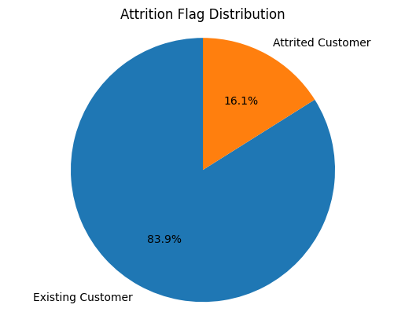

```python
plt.pie(df['Attrition_Flag'].value_counts(), labels=df['Attrition_Flag'].value_counts().index, autopct='%1.1f%%', startangle=90)
plt.title('Attrition Flag Distribution')
plt.axis('equal');
```

##### Observations:

- The majority of customers, approximately *83.9%* of the total (*8500 customers*), are *Existing Customers*, while, *Attrited Customers* (*1627 customers, 16.1%*), indicating a noticeable churn rate that requires further analysis.

#### Distribution of **`Gender`** *(Categorical Column)*

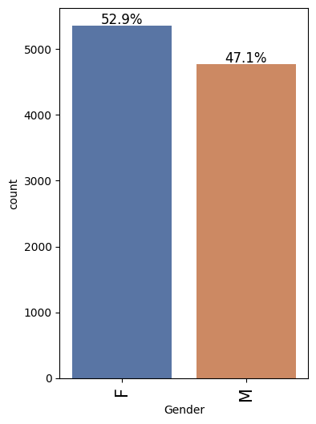

```python
labeled_barplot(df, 'Gender', perc=True);
```

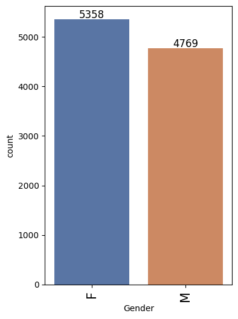

```python
labeled_barplot(df, 'Gender');
```

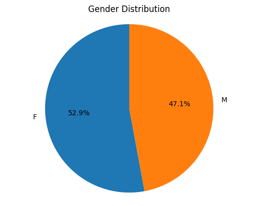

```python
plt.pie(df['Gender'].value_counts(), labels=df['Gender'].value_counts().index, autopct='%1.1f%%', startangle=90)
plt.title('Gender Distribution')
plt.axis('equal');
```

##### Observations:

- **Slight Female Majority:** *Females (52.9%)* slightly outnumber *Males (47.1%)* in the dataset.